# House Prices Kaggle

Load all the packages needed

```r
library(tidymodels)
```

```
* Use tidymodels_prefer() to resolve common conflicts.
```

```r
library(tidyverse)
library(skimr)
library(parsnip)
library(ranger)
library(yardstick)
library(glmnet)
library(earth)
```

Load the data sets

```r
setwd("~/R projects/House Prices")
train <- read_csv("train.csv")
test <- read_csv("test.csv")
```

EDA Lets look at how the SalePrices are distributed

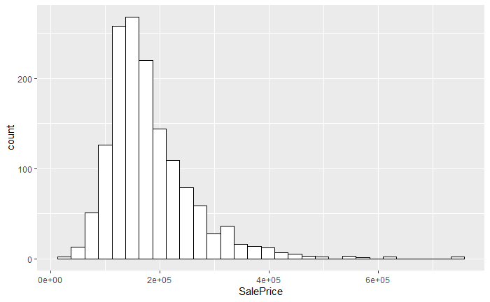

```r
ggplot(train,
       aes(x = SalePrice)) +
  geom_histogram(fill = "white", color = "black")
```

I don’t like the shape of the distribution of SalePrice so lets try making it look more symmetric with a log transformation.

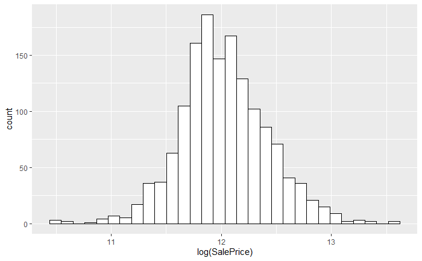

```r
ggplot(train, aes(x = log(SalePrice))) +
  geom_histogram(fill = "white", color = "black")
```

This is much better. We could try more kinds of transformations like inverse, power or BoxCox but I think this looks good enough. However, lets do the transformation and then remove observations that have a boxplot’s definition of outlier for SalePrice.

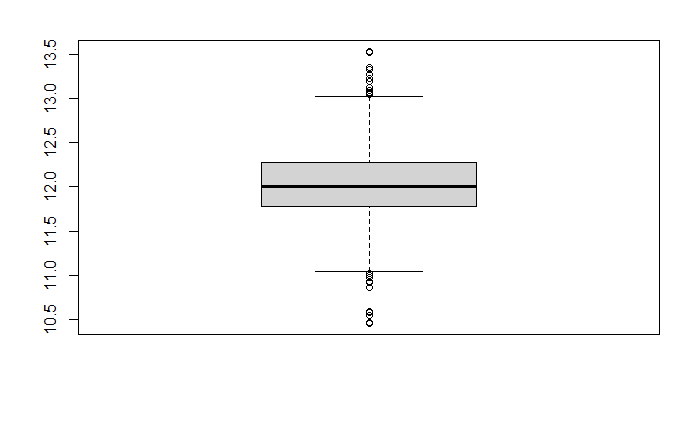

```r
train$SalePrice <- log(train$SalePrice)
sale_upper <- boxplot(train$SalePrice)$stats[5]
```

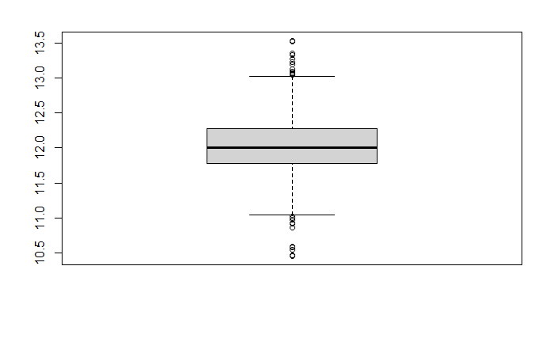

```r
sale_lower <- boxplot(train$SalePrice)$stats[1]
```

```r
train <- train %>%
  filter(SalePrice < sale_upper, SalePrice > sale_lower)
```

Lets check some other features and their relationship to SalePrice

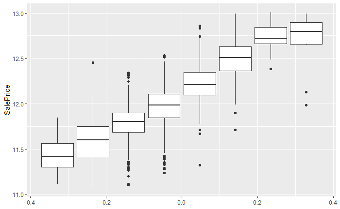

```r
ggplot(train,
       aes(y = SalePrice,
           group = OverallQual)) +
  geom_boxplot()
```

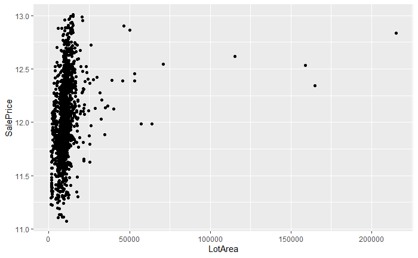

```r
ggplot(train,
       aes(y = SalePrice,
           x = LotArea)) +
  geom_point()
```

Data Cleaning

Now it is time to clean our datasets. For this I combine the train and test dataset. I am going to remove columns which have more that 25% missing values. Also I remove Street and Utilties because they have a very small variance.

```r
test$SalePrice <- 0
full <- rbind(test, train)
skim(full)
```

```
-- Data Summary ------------------------
                           Values
Name                       full
Number of rows             2889
Number of columns          81
_______________________
Column type frequency:
  character                43
  numeric                  38
________________________
Group variables            None

-- Variable type: character ------------------------------------------------------------------------------------------------
# A tibble: 43 x 8
   skim_variable n_missing complete_rate   min   max empty n_unique whitespace
```

[output cut: 87 more lines]

```r
remove_cols <- colnames(full)[colSums(is.na(full)) > (0.25 * nrow(full))]
full <- full %>%
  select(!remove_cols)
```

```
Note: Using an external vector in selections is ambiguous.
i Use `all_of(remove_cols)` instead of `remove_cols` to silence this message.
i See <https://tidyselect.r-lib.org/reference/faq-external-vector.html>.
```

```r
full <- full %>%
  select(!c(Street, Utilities))

train <- full %>%
  filter(SalePrice != 0)
test <- full %>%
  filter(SalePrice == 0)
```

Now we split the training data

```r
set.seed(135)
data_split <- initial_split(train, strata = "SalePrice", prop = 0.80)

house_test <- testing(data_split)
house_train <- training(data_split)
```

Here I am doing all the preprocessing.

```r
house_rec <- recipe(SalePrice ~., data = house_train) %>%
  step_impute_mode(all_nominal_predictors()) %>%
  step_impute_mean(all_numeric_predictors()) %>%
  update_role(Id, new_role = "ID") %>%
  step_dummy(all_nominal_predictors()) %>%
  step_impute_median(all_predictors()) %>%
  step_BoxCox(all_numeric_predictors()) %>%
  step_nzv(all_predictors()) %>%
  step_normalize(all_numeric_predictors())
```

Modeling

For some of the models I will be tuning the hyperparameters and will be doing so using a 5-fold crossvalidation.

```r
set.seed(123)
folds <- vfold_cv(house_train, v = 5)
```

Random Forest Model - Model

```r
rf_mod <-
  rand_forest(trees = 1000, mtry = tune(), min_n = tune()) %>%
  set_mode("regression") %>%
  set_engine("ranger")
```

Random Forest - Workflow

```r
rf_wf <- workflow() %>%
  add_recipe(house_rec) %>%
  add_model(rf_mod)
```

Random Forest - Grid for tuning

```r
rf_grid <- grid_regular(
  mtry(range = c(10, 30)),
  min_n(range = c(2, 8)),
  levels = 5
)
```

Random Forest - Tune and update the parameters

```r
set.seed(345)
tune_res <- tune_grid(
  rf_wf,
  resamples = folds,
  grid = rf_grid
)
```

[output not shown]

[output cut: 70 more lines]

[output not shown]

```r
best_rmse <- select_best(tune_res, "rmse")
final_rf <- finalize_model(
  rf_mod,
  best_rmse
)
rf_wf <- rf_wf %>%
  update_model(final_rf)
```

Random Forest - Fit the model

```r
rf_fit <- fit(rf_wf, data = house_train)
```

Random Forest - Predict and find the RMSE

```r
rf_pred <- rf_fit %>%
  predict(new_data = house_test)
rf_pred <- bind_cols(rf_pred, house_test %>% select(SalePrice))
rf_pred
```

| .pred | SalePrice |
| --- | --- |
| 12.49403 | 12.63460 |
| 11.72263 | 11.67844 |
| 11.78142 | 11.79056 |
| 11.90700 | 11.91170 |
| 11.77749 | 11.84510 |
| 12.20063 | 12.10016 |
| 12.06326 | 12.01673 |
| 11.93233 | 11.93819 |
| 11.66179 | 11.63514 |
| 12.64341 | 12.99175 |

[output cut: 278 more lines]

```r
rmse(rf_pred, truth = exp(SalePrice), estimate = exp(.pred))
```

| .metric | .estimator | .estimate |
| --- | --- | --- |
| rmse | standard | 29029 |

Random Forest - Plot the predictions against the actual SalePrice and see if there any postProcesses that can be done.

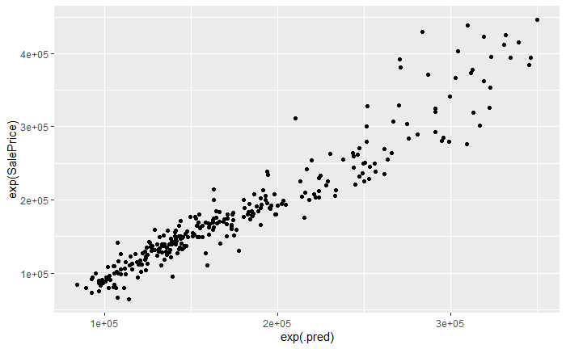

```r
ggplot(data = rf_pred, aes(x = exp(.pred), y = exp(SalePrice))) +
  geom_point()
```

Does not look like any postProcessing is needed.

LASSO Model Same Process as with Random Forest

```r
lasso_model <- linear_reg(penalty = tune(), mixture = tune()) %>%
  set_engine("glmnet")


lasso_wf <- workflow() %>%
  add_recipe(house_rec) %>%
  add_model(lasso_model)

lasso_grid <- grid_regular(
  penalty(), # The tune package has default values for penalty() and mixture() so no need to give them any
  mixture(),
  levels = 5
)
set.seed(345)
tune_res_las <- tune_grid(
  lasso_wf,
  resamples = folds,
  grid = lasso_grid
)
```

[output not shown]

```r
best_rmse_las <- select_best(tune_res_las, "rmse")
final_las <- finalize_model(
  lasso_model,
  best_rmse_las
)
lasso_wf <- lasso_wf %>%
  update_model(final_las)
```

LASSO - Fit the model

```r
lasso_fit <- fit(lasso_wf, data = house_train)
```

LASSO - Predict and evaluate using RMSE

```r
lasso_pred <- lasso_fit %>%
  predict(new_data = house_test)
lasso_pred <- bind_cols(lasso_pred, house_test %>% select(SalePrice))
rmse(lasso_pred, truth = exp(SalePrice), estimate = exp(.pred))
```

| .metric | .estimator | .estimate |
| --- | --- | --- |
| rmse | standard | 27997.47 |

LASSO - Check for any potential postProcessing

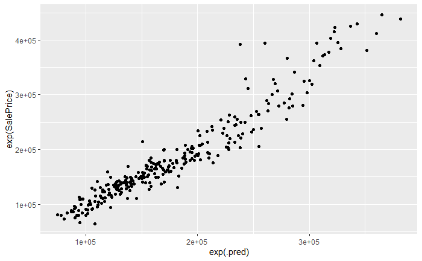

```r
ggplot(data = lasso_pred, aes(x = exp(.pred), y = exp(SalePrice))) +
  geom_point()
```

Looks good, no postProcessing required

MARS Model For the MARS model I am not going to use parameter tuning

```r
mars_model <- mars(mode = "regression") %>%
  set_engine("earth")

mars_wf <- workflow() %>%
  add_recipe(house_rec) %>%
  add_model(mars_model)

mars_fit <- fit(mars_wf, data = house_train)
```

MARS - Prediction and evaluate using RMSE

```r
mars_pred <- mars_fit %>%
  predict(new_data = house_test)
mars_pred <- bind_cols(mars_pred, house_test %>% select(SalePrice))
rmse(mars_pred, truth = exp(SalePrice), estimate = exp(.pred))
```

| .metric | .estimator | .estimate |
| --- | --- | --- |
| rmse | standard | 28163.8 |

MARS - Check for any postProcessing

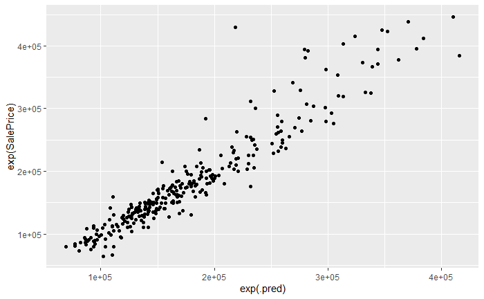

```r
ggplot(data = mars_pred, aes(x = exp(.pred), y = exp(SalePrice))) +
  geom_point()
```

Looks good, no postProcessing required.

Submission From the RMSE scores it looks like the LASSO model worked best so that is what I am going to use for the final prediction.

```r
lasso_final_fit <- fit(lasso_wf, data = train)
lasso_final_pred <- predict(lasso_final_fit, new_data = test)
lasso_final_pred <- bind_cols(test %>% select(Id), exp(lasso_final_pred))
names(lasso_final_pred)[2] <- "SalePrice"

write_csv(lasso_final_pred, "tidymodels_pred.csv")
```

[output not shown]

This gave me a 0.13401 score on Kaggle.